# Overview of the ‘pals’ package

Kevin Wright

2024-07-15

The purpose of the `pals` package is twofold:

1. Provide a comprehensive collection of color palettes and colormaps
2. Provide tools for evaluating these collections.

Memory use is reduced by compressing colormaps to fewer colors and by calling `colorRampPalette` only when a colormap is requested.

This report gives some suggestions/recommendations for color and then gives an example of each evaluation tool.

# Recommendations

The appearance of color depends on:

1. The display device (laptop/monitor, projector, paper, photocopy).
2. The type of graphic (regions, lines).
3. The person viewing the graphic (age, gender, colorblindness)

It is difficult to give definitive recommendations for the best palettes and colormaps. Nonetheless, here are some we like.

Diverging: `coolwarm`/`warmcool` (avoid Mach banding in the middle).

Sequential (multi-hue): `ocean.haline`, `parula` (default in Matlab).

Sequential (one hue): `brewer.blues`.

Rainbow: `cubicl`, `kovesi.rainbow`.

Cyclical: `ocean.phase`.

Categorical: `brewer.paired`, `stepped`

Bivariate: `brewer.seqseq2`.

```r
require(pals)
pal.bands(coolwarm, parula, ocean.haline, brewer.blues, cubicl, kovesi.rainbow, ocean.phase, brewer.paired(12), stepped, brewer.seqseq2,
          main="Colormap suggestions")
```

```
## Only 24 colors are available with 'stepped'
```

```
## Only 9 colors are available with 'brewer.seqseq2'
```

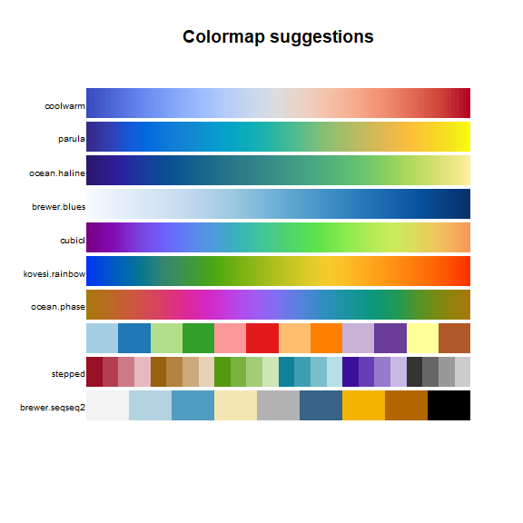

# Functions in the `pals` package

## pal.bands()

Show palettes and colormaps as colored bands

### What to look for:

1. A good discrete palette has distinct colors.
2. A good continuous colormap does not show boundaries between colors.

The graphic below shows what we consider to be major flaw of the viridis palette…nearly half of the palette is more or less a green color.

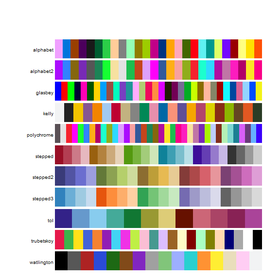

```r
require(pals)
op=par(mar=c(0,5,3,1))
labs=c('alphabet','alphabet2', 'glasbey','kelly','polychrome', 'stepped', 'stepped2', 'stepped3', 'tol', 'trubetskoy','watlington')
pal.bands(alphabet(), alphabet2(), glasbey(), kelly(),
          polychrome(), stepped(), stepped2(), stepped3(),
          tol(), trubetskoy(),
          watlington(), labels=labs, show.names=FALSE)
```

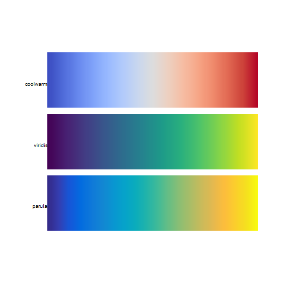

```r
par(op)
pal.bands(coolwarm, viridis, parula, n=200)
```

## pal.channels()

Show the amount of red, green, blue, and gray in colors of a palette. The gray line corresponds to luminosity.

### What to look for:

1. Sequential data should usually be shown with a colormap that is smoothly increasing in lightness, as shown by the gray line.

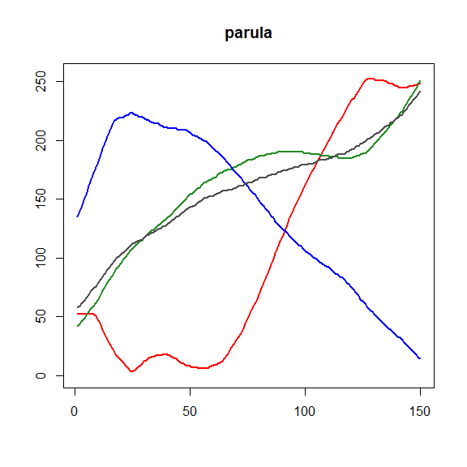

```r
pal.channels(parula, main="parula")
```

## pal.cluster()

Show a palette with hierarchical clustering

The palette colors are converted to LUV coordinates before clustering.

### What to look for:

1. Colors that are visually similar tend to be clustered together.
2. Leaves of the dendrogram should not be at substantially different heights.

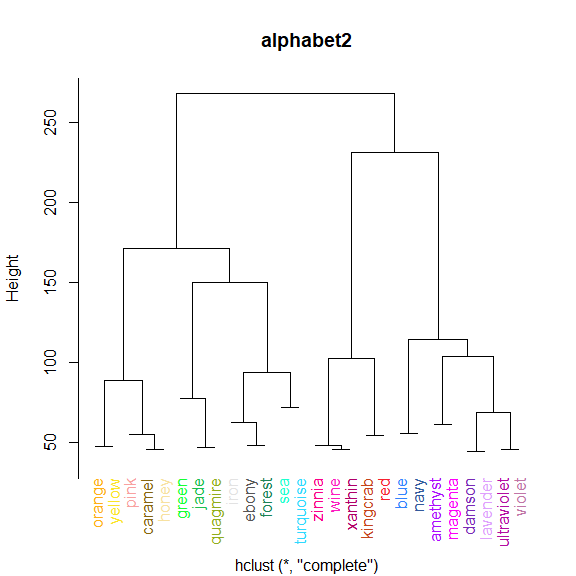

```r
pal.cluster(alphabet2(), main="alphabet2")
```

## pal.compress()

A few colormaps in the `pals` package are defined with mathematical formulas (e.g. the cubehelix colormap), but most of the colormaps are originally defined as a smooth curve through a seqence of 256 colors. There seems to be no theoretical reason for 256 colors, other than tradition. It is natural to wonder if a smooth curve through fewer colors would be equally sufficient. This function compresses a colormap function down to a small-ish vector of colors that can be passed into `colorRampPalette` to re-create the original palette with a non-noticeable difference. Most of the palettes in the `pals` package are stored as a compressed sequence of colors.

How effective is `pal.compress`? Compressing all 50 `kovesi.*` colormaps reduced memory from a needlessly wasteful 352000 bytes down to 46000 bytes, a savings of 87%.

In the figure below, the top band is the (mathematically-defined) `cubehelix` colormap function evaluated at 255 colors. These 256 colors are compressed to 17 colors in the `cubebasis` vector (shown in the middle). These 17 colors are passed into the `colorRampPalette` function and expanded to 255 colors shown in the bottom band. The maximum squared LUV distance between the individual colors in the two bands is only 2.34, which is smaller than the theoretical perceptual difference of roughly 2.5.

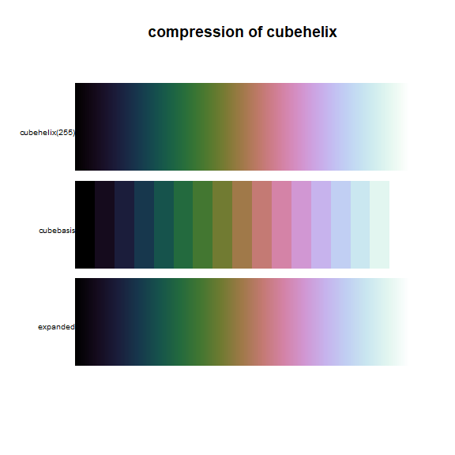

```r
# smooth palettes are usually easy to compress
p1 <- cubehelix(255)
cubebasis <- pal.compress(cubehelix)
p2 <- colorRampPalette(cubebasis)(255)
pal.bands(p1, cubebasis, p2,
  labels=c('cubehelix(255)', 'cubebasis','expanded'), main="compression of cubehelix")
```

```r
pal.maxdist(p1,p2) # 2.08
```

```
## [1] 2.337919
```

## pal.csf()

Show a colormap with a Campbell-Robson Contrast Sensitivity Chart.

In a contrast sensitivity figure as drawn by this function, the spatial frequency increases from left to right and the contrast decreases from bottom to top. The bars in the figure appear taller in the middle of the image than at the edges, creating an upside-down “U” shape, which is the “contrast sensitivity function”. Your perception of this curve depends on the viewing distance.

### What to look for:

1. Are the vertical bands visible across the full vertical axis?
2. Do the vertical bands blur together along the right side?

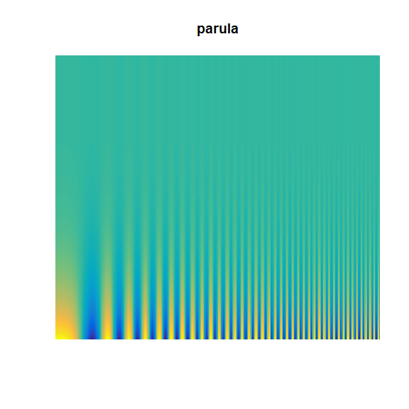

```r
pal.csf(parula, main="parula")
```

## pal.cube()

The palette is converted to RGB or LUV coordinates and plotted in a three-dimensional scatterplot. The LUV space is probably better, but it is easier to tweak colors by hand in RGB space.

### What to look for:

1. A good palette has colors that are spread somewhat uniformly in 3D.

```r
#pal.cube(cubehelix)
#pal.cube(polychrome())
```

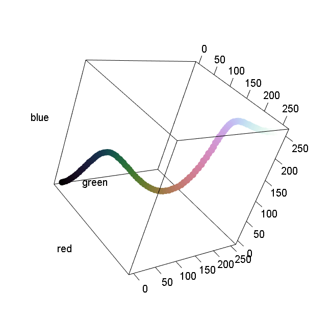

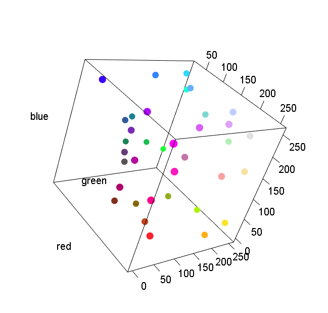

## pal.heatmap()

A random heatmap is generated (with 5% missing values) and a key is added to the heatmap by appending a blank column along the right side and then a column with the palette colors.

### What to look for:

1. Can the value of each cell be correctly inferred using the key on the right side?
2. Can missing values be identified?

The graphic below shows that the `alphabet2` palette is dominated by red/pink/purple colors.

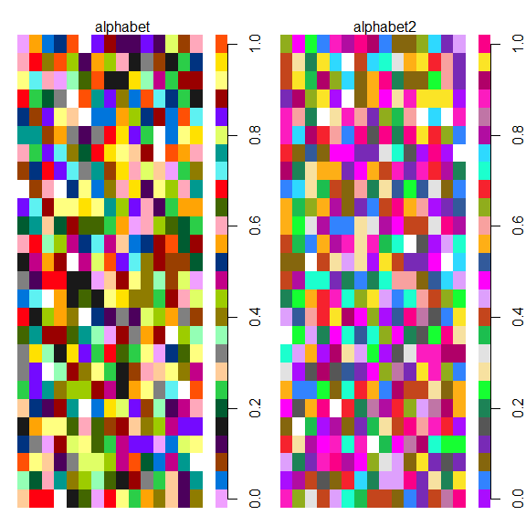

```r
op <- par(mfrow=c(1,2), mar=c(1,1,2,2))
pal.heatmap(alphabet, n=26, main="alphabet")
pal.heatmap(alphabet2, n=26, main="alphabet2")
```

```r
par(op)
```